# Basic package description

To limit this documentation size, most figures are not displayed in the version of the vignette included in the package. To see all figures, you can rerun the vignettes, changing the following option to `TRUE`:

```r
knitr::opts_chunk$set(include = FALSE)
```

Alternatively, this compilation is also available at: http://sombrero.nathalievialaneix.eu/articles/d-doc-korrespSOM.html

## Basic package description

`SOMbrero` implements different variants of the Self-Organizing Map algorithm (also called Kohonen's algorithm). To process a given dataset with the SOM algorithm, you can use the function `trainSOM()`.

**This documentation only considers the case of contingency tables.**

### Arguments

The `trainSOM` function has several arguments, but only the first one is required. This argument is `x.data` which is the dataset used to train the SOM. In this documentation, it is passed to the function as a matrix or a data frame and encodes a contingency tables (the entries are the frequencies of joint observations for two factors). Column and row names must be supplied to ease the interpretation.

The function handles over options, which are the same as the ones passed to `initSOM` (they are parameters defining the algorithm, see `help(initSOM)` for further details).

### Outputs

The `trainSOM` function returns an object of class `somRes` (see `help(trainSOM)` for further details on this class).

## Case study: the `presidentielles2002` data set

The `presidentielles2002` data set provides the number of votes for the first round of the 2002 French presidential election for each of the 16 candidates in all of the 106 French administrative districts called “départements”. Further details about this data set and the 2002 French presidential election are given with `help(presidentielles2002)`.

```r
data(presidentielles2002)
apply(presidentielles2002, 2, sum)
```

```
##      MEGRET      LEPAGE  GLUCKSTEIN      BAYROU      CHIRAC      LE_PEN
##      667043      535875      132696     1949219     5666021     4804772
##     TAUBIRA SAINT_JOSSE      MAMERE      JOSPIN      BOUTIN         HUE
##      660515     1204801     1495774     4610267      339157      960548
## CHEVENEMENT     MADELIN   LAGUILLER  BESANCENOT
##     1518568     1113551     1630118     1210562
```

(the two candidates that ran the second round of the election were Jacques Chirac and the far-right candidate Jean-Marie Le Pen)

### Training the SOM

```r
set.seed(01091407)
korresp.som <- trainSOM(x.data = presidentielles2002, dimension = c(8,8),
                        type = "korresp", scaling = "chi2", nb.save = 10,
                        topo = "hexagonal", maxit = 500)
korresp.som
```

```
##       Self-Organizing Map object...
##          online learning, type: korresp
##          8 x 8 grid with hexagonal topology
##          neighbourhood type: gaussian
##          distance type: euclidean
```

As the energy is registered during the intermediate backups, we can take a look at its evolution

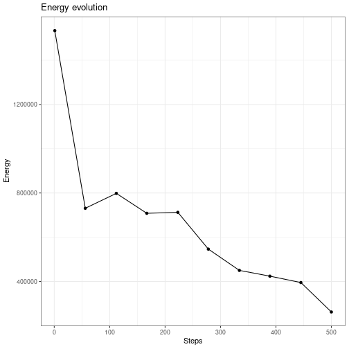

```r
plot(korresp.som, what = "energy")
```

### Resulting clustering

The clustering component contains the final classification of the dataset. As both row and column variables are classified, the length of the resulting vector is equal to the sum of the number of rows and the number of columns.

**NB: The clustering component shows first the column variables (here, the candidates) and then the row variables (here, the départements).**

```r
korresp.som$clustering
```

```
##                   MEGRET                   LEPAGE               GLUCKSTEIN
##                        8                        8                        8
##                   BAYROU                   CHIRAC                   LE_PEN
##                       40                       33                       61
##                  TAUBIRA              SAINT_JOSSE                   MAMERE
##                        8                        4                       32
##                   JOSPIN                   BOUTIN                      HUE
##                       25                        8                        6
##              CHEVENEMENT                  MADELIN                LAGUILLER
##                       32                       24                        4
##               BESANCENOT                      ain                    aisne
##                        5                       61                       61
##                   allier  alpes_de_haute_provence             hautes_alpes
##                       59                       57                       57
##          alpes_maritimes                  ardeche                 ardennes
##                       64                       59                       57
##                   ariege                     aube                     aude
##                       57                       57                       59
##                  aveyron         bouches_du_rhone                 calvados
##                       57                        4                       53
##                   cantal                 charente        charente_maritime
##                       57                       57                       43
##                     cher                  correze                corse_sud
##                       57                       57                       57
##              haute_corse                cote_d'or            cotes_d'armor
##                       57                       61                       25
##                   creuse                 dordogne                    doubs
##                       57                       59                       61
##                    drome                     eure             eure_et_loir
##                       60                       61                       59
##                finistere                     gard            haute_garonne
##                       17                       62                        9
##                     gers                  gironde                  herault
##                       57                        1                       55
##          ille_et_vilaine                    indre          indre_et_loire_
##                       17                       57                       61
##                    isere                     jura                   landes
##                       56                       57                       57
##             loir_et_cher                    loire              haute_loire
##                       59                       63                       57
```

[output cut: 27 more lines]

```
##                       64                       61                       25
##                   vienne             haute_vienne                   vosges
##                       58                       49                       59
##                    yonne    territoire_de_belfort                  essonne
##                       59                       57                       46
##          hauts_de_seine_        seine_saint-denis             val_de_marne
##                       40                       37                       46
##               val_d'oise               guadeloupe               martinique
##                       55                       57                       57
##                   guyane               la_reunion                  mayotte
##                       57                       33                       57
##       nouvelle_caledonie      polynesie_francaise saint_pierre_et_miquelon
##                       57                       57                       57
##         wallis_et_futuna   francais_de_l'etranger
##                       57                       49
```

The following table indicates which graphics are available for a korresp SOM.

| What SOM or SC Type | SOM Energy | Obs | Prototypes | Add | SuperCluster (no what) | Obs | Prototypes | Add |
| --- | --- | --- | --- | --- | --- | --- | --- | --- |
| (no type) | x |  |  |  |  |  |  |  |
| hitmap |  | x |  |  |  | x |  |  |
| color |  |  | x |  |  |  | x |  |
| lines |  |  | x |  |  |  | x |  |
| barplot |  |  | x |  |  |  | x |  |
| 3d |  |  | x |  |  |  |  |  |
| poly.dist |  |  | x |  |  |  | x |  |
| umatrix |  |  | x |  |  |  |  |  |
| smooth.dist |  |  | x |  |  |  |  |  |
| mds |  |  | x |  |  |  | x |  |
| grid.dist |  |  | x |  |  |  |  |  |
| names |  | x |  |  |  |  |  |  |
| grid |  |  |  |  |  |  | x |  |
| dendrogram |  |  |  |  | x |  |  |  |
| dendro3d |  |  |  |  | x |  |  |  |

The resulting distribution of the clustering on the map can also be visualized by a hitmap:

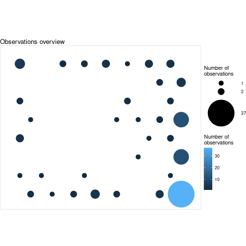

```r
plot(korresp.som, what = "obs", type = "hitmap", show.names = FALSE)
```

For a more precise view, `"names"` plot is implemented: the names of the values assigned to every neuron is displayed in the corresponding cluster. In `korresp` SOM, both row and column names are displayed.

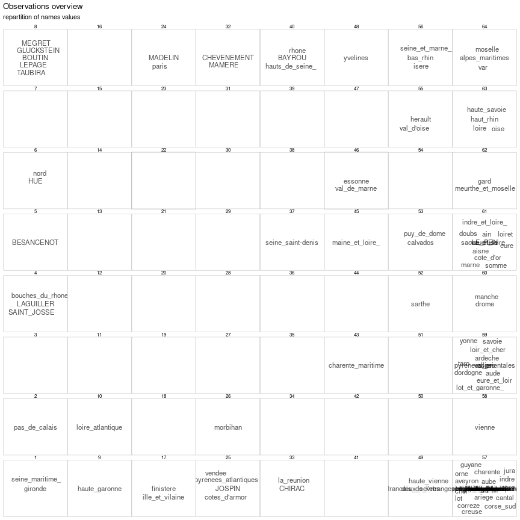

```r
plot(korresp.som, what="obs", type="names")
```

The map is divided into two main parts: minor candidates are classified at its top left hand side whereas the first main candidates CHIRAC, LE PEN and JOSPIN are classified at the bottom right hand side of the map, in three different parts of this corner. Some striking facts are:

- most of rural départements (Corrèze, Creuse, Jura, Cantal, Ariège, …) are classified in the bottom right corner, in between CHIRAC and LE PEN, who have high number of votes (compared to the other candidates) in these département;
- CHIRAC is characterized by higher votes for La Réunion (oversee département) whereas LE PEN has higher votes for Indre Et Loire, Aisne, Loiret, Côte d'Or;
- some well known associations, like HUE (communist party) in the Nord, are also visible on the map.

### Clustering interpretation

Some graphics from the numeric SOM algorithm are still available in the korresp case. They are detailed below. As the resulting clustering provides the classification for both rows and columns, a new argument `view` is used to specify which one should be considered. Its possible values are either `"r"` for row variables (the default value) or `"c"` for column variables.

#### Graphics on prototype values

Three representations are available:

- with lines: either all rows or all columns are displayed (`view` argument is used)

The département profiles are much flatter (and with low values) in the top left corner of the map than in the bottom right corner which shows more differences between département and globally higher number of votes.

On the contrary, the candidate profiles are flatter, with globally lower values in the bottom right corner of the map.

A more precise individual view are given with the graphics “color” and “3d”, here drawn, as an example for the candidate “LE PEN” and for the département “La Réunion”.

- in color: one of the row or column variable (the variable is chosen with the argument `variable`) is represented on the map;
- in 3d, which handling is similar to `"color"`.

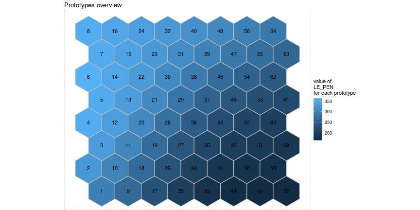

```r
plot(korresp.som, what = "prototypes", type = "color", variable = "LE_PEN")
```

The first graphic shows that LE_PEN obtained more votes in the departements located at the top left corner of the map. The second graphic shows that the candidates that obtained the highest scores in La Réunion are located at the bottom of the map (like Chirac).

The graphics can also be drawn by giving the variable number and its type, either “r” or “c” (here, as an example, CHIRAC who is the 5th candidate, 5th column):

Hence CHIRAC obtained more votes in departement located at the left hand side of the map.

#### Graphic on prototype distances

These graphics are exactly the same as in the numerical case and provide various way to display the distance between prototypes on the grid.

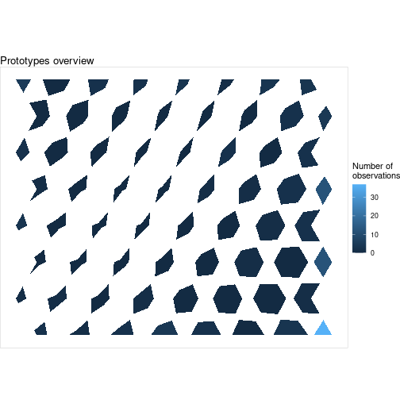

```r
plot(korresp.som, what = "prototypes", type = "poly.dist", show.names = FALSE)
```

All these graphics show a clear separation between the top left corner of the map and the bottom right corner of the map.

### Analyze the projection quality

The quality of the projection is provided by the function `quality` that outputs the same quality criteria than in the numeric case.

```r
quality(korresp.som)
```

```
## $topographic
## [1] 0.1603774
##
## $quantization
## [1] 60033.83
```

### Building super classes from the resulting SOM

A usual way to address clustering with SOM is to perform a hierarchical clustering on the prototypes. This clustering is directly available in the package `SOMbrero` using the function `superClass`. To do so, you can first have a quick overview to decide on the number of super clusters which suits your data.

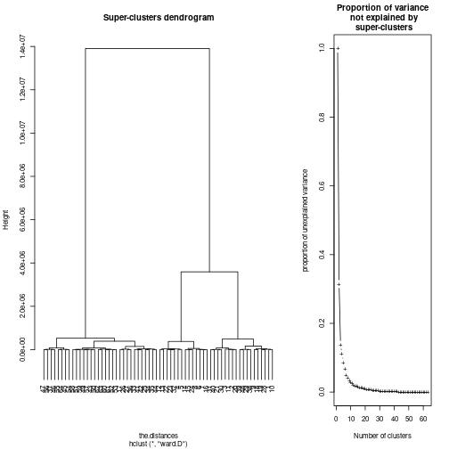

```r
plot(superClass(korresp.som))
```

By default, the function plots both a dendrogram and the evolution of the percentage of explained variance. Here, 3 super clusters seem to be a good choice. The output of `superClass` is a `somSC` class object. Basic functions have been defined for this class:

```r
my.sc <- superClass(korresp.som, k = 3)
summary(my.sc)
```

```
##
##    SOM Super Classes
##      Initial number of clusters :  64
##      Number of super clusters   :  3
##
##
##   Frequency table
##  1  2  3
## 18 14 32
##
##   Clustering
##  1  2  3  4  5  6  7  8  9 10 11 12 13 14 15 16 17 18 19 20 21 22 23 24 25 26
##  1  1  1  2  2  2  2  2  1  1  1  2  2  2  2  2  3  1  1  1  1  2  2  2  3  3
## 27 28 29 30 31 32 33 34 35 36 37 38 39 40 41 42 43 44 45 46 47 48 49 50 51 52
##  3  1  1  1  1  2  3  3  3  3  3  1  1  1  3  3  3  3  3  3  3  1  3  3  3  3
## 53 54 55 56 57 58 59 60 61 62 63 64
##  3  3  3  3  3  3  3  3  3  3  3  3
```

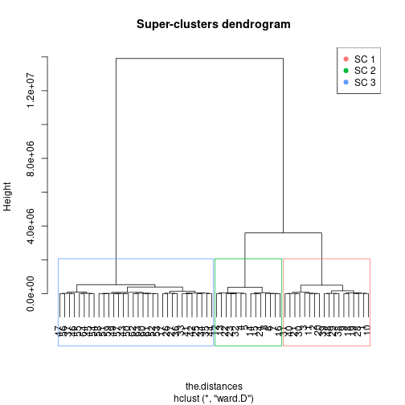

```r
plot(my.sc, plot.var = FALSE)
```

Like `plot.somRes`, the function `plot.somSC` has an argument `'type'` which offers many different plots and can thus be combined with most of the graphics produced by `plot.somSC`:

- Case `"grid"` fills the grid with colors according to the super clustering (and can provide a legend).
- Case `"dendro3d"` plots a 3d dendrogram.

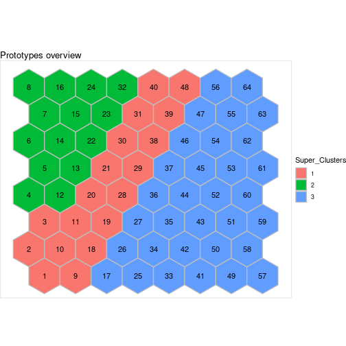

```r
plot(my.sc, type = "grid")
```

The three super-clusters correspond to most voted candidates (blue), less voted candidates (green) and, in between, départments with intermediate votes in which BAYROU (from one of the center party) are classified.

A couple of plots from `plot.somRes` are also available for the super clustering. Some identify the super clusters with colors:

And some others identify the super clusters with titles: